# Data 606 Lab 4: The Normal Distribution

## Normal probabilities

Okay, so now you have a slew of tools to judge whether or not a variable is normally distributed. Why should you care?

It turns out that statisticians know a lot about the normal distribution. Once you decide that a random variable is approximately normal, you can answer all sorts of questions about that variable related to probability. Take, for example, the question of, “What is the probability that a randomly chosen Dairy Queen product has more than 600 calories from fat?”

If we assume that the calories from fat from Dairy Queen’s menu are normally distributed (a very close approximation is also okay), we can find this probability by calculating a Z score and consulting a Z table (also called a normal probability table). In R, this is done in one step with the function `pnorm()`.

```r
1 - pnorm(q = 600, mean = dqmean, sd = dqsd)
```

```
## [1] 0.01501523
```

Note that the function `pnorm()` gives the area under the normal curve below a given value, `q`, with a given mean and standard deviation. Since we’re interested in the probability that a Dairy Queen item has more than 600 calories from fat, we have to take one minus that probability.

Assuming a normal distribution has allowed us to calculate a theoretical probability. If we want to calculate the probability empirically, we simply need to determine how many observations fall above 600 then divide this number by the total sample size.

```r
dairy_queen %>%
  filter(cal_fat > 600) %>%
  summarise(percent = n() / nrow(dairy_queen))
```

```
## # A tibble: 1 × 1
##   percent
##     <dbl>
## 1  0.0476
```

Although the probabilities are not exactly the same, they are reasonably close. The closer that your distribution is to being normal, the more accurate the theoretical probabilities will be.

6. Write out two probability questions that you would like to answer about any of the restaurants in this dataset. Calculate those probabilities using both the theoretical normal distribution as well as the empirical distribution (four probabilities in all). Which one had a closer agreement between the two methods?

Answer: 1. What is the probability that a Taco Bell meal has more than 400 calories?

Theoretical probability: 0.5936 Empircal: 0.557

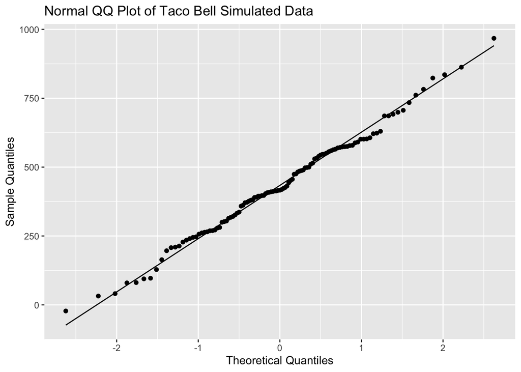

```r
tcbdata <- subset(fastfood, restaurant == "Taco Bell")

tcb_mean <- mean(tcbdata$calories)
tcb_sd <- sd(tcbdata$calories)

tcb_sim_norm <- rnorm(n = nrow(tcbdata), mean = tcb_mean, sd = tcb_sd)

ggplot() +
  geom_qq(aes(sample = tcb_sim_norm)) +
  geom_qq_line(aes(sample = tcb_sim_norm)) +
  labs(title = "Normal QQ Plot of Taco Bell Simulated Data",
       x = "Theoretical Quantiles",
       y = "Sample Quantiles")
```

```r
#theoretical
1 - pnorm(q = 400, mean = tcb_mean, sd = tcb_sd)
```

```
## [1] 0.5935926
```

```r
#empircal
tcbdata %>%
  filter(calories > 400) %>%
  summarise(percent = n() / nrow(tcbdata))
```

```
## # A tibble: 1 × 1
##   percent
##     <dbl>
## 1   0.557
```

2. What is the probability that a Subway meal has between 400 and 600 calories?

Theoretical: 0.277 Emperical: 0.198

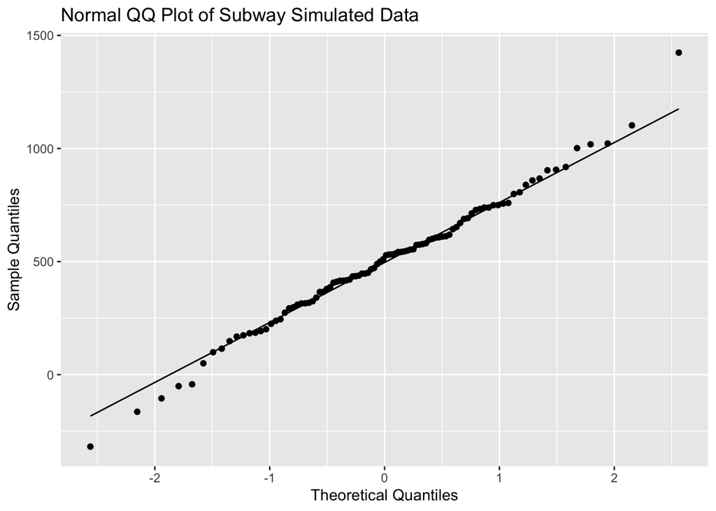

```r
eatfresh <- subset(fastfood, restaurant == "Subway")

sub_mean <- mean(eatfresh$calories)
sub_sd <- sd(eatfresh$calories)

sub_sim_norm <- rnorm(n = nrow(eatfresh), mean = sub_mean, sd = sub_sd)

ggplot() +
  geom_qq(aes(sample = sub_sim_norm)) +
  geom_qq_line(aes(sample = sub_sim_norm)) +
  labs(title = "Normal QQ Plot of Subway Simulated Data",
       x = "Theoretical Quantiles",
       y = "Sample Quantiles")
```

```r
#theoretical probability
pnorm(600, mean = sub_mean, sd = sub_sd) - pnorm(400, mean = sub_mean, sd = sub_sd)
```

```
## [1] 0.2768949
```

```r
#empirical probability
eatfresh %>%
  filter(calories > 400 & calories <= 600) %>%
  summarise(percent = n() / nrow(eatfresh))
```

```
## # A tibble: 1 × 1
##   percent
##     <dbl>
## 1   0.198
```

## More Practice

7. Now let’s consider some of the other variables in the dataset. Out of all the different restaurants, which ones’ distribution is the closest to normal for sodium?

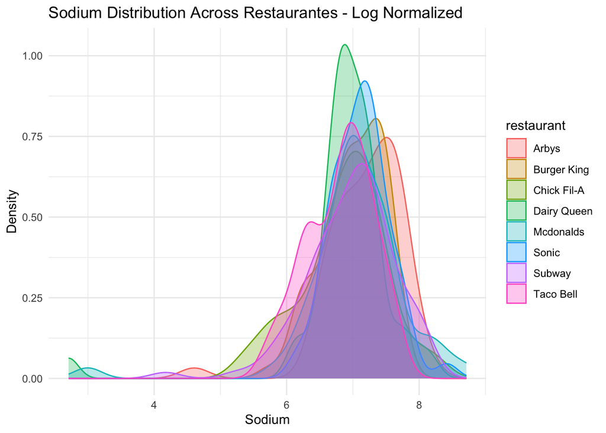

```r
sodium_cut <- fastfood %>%
  filter(!is.na(sodium)) %>%
  mutate(log_sodium = log(sodium))

sod_mean <- mean(sodium_cut$sodium)
sod_sd <- sd(sodium_cut$sodium)

ggplot(sodium_cut, aes(x = log_sodium, color = restaurant, fill = restaurant)) +
  geom_density(alpha = 0.3) +
  labs(title = "Sodium Distribution Across Restaurantes - Log Normalized",
       x = "Sodium",
       y = "Density") +
  theme_minimal()
```

[figure not shown]

```r
ggplot(sodium_cut, aes(x = log_sodium)) +
  geom_blank() +
  geom_histogram(aes(y = ..density..), binwidth = 20) +
  stat_function(fun = dnorm, args = c(mean = sod_mean, sd = sod_sd), col = "skyblue")
```

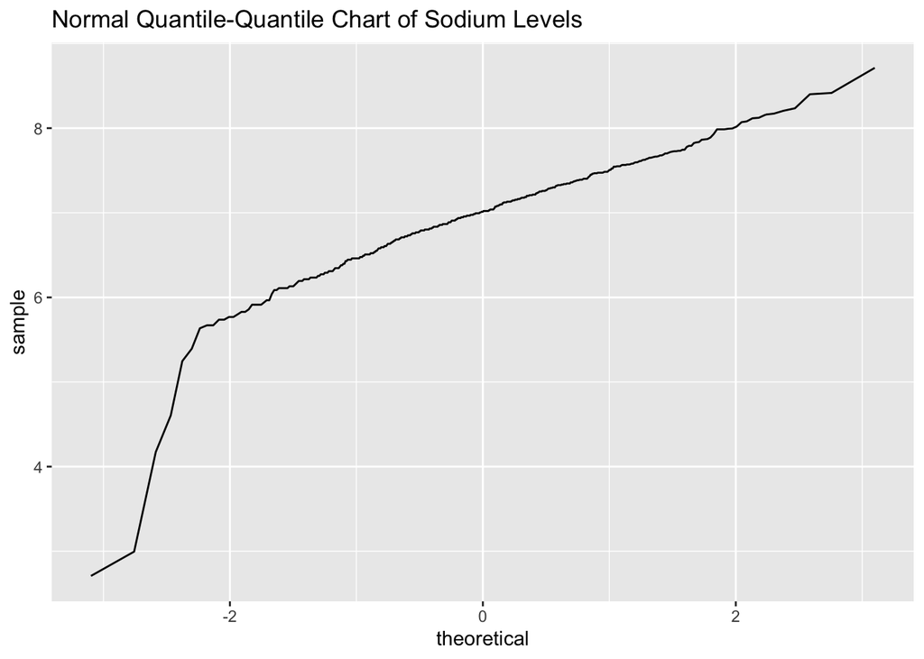

```r
ggplot(data = sodium_cut, aes(sample = log_sodium)) +
  geom_line(stat = "qq") +
  labs(title = "Normal Quantile-Quantile Chart of Sodium Levels")
```

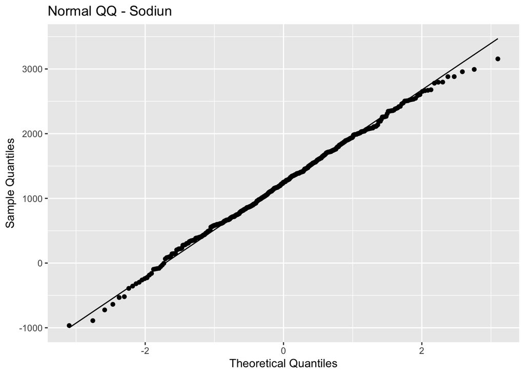

```r
sod_sim_norm <- rnorm(n = nrow(sodium_cut), mean = sod_mean, sd = sod_sd)

ggplot() +
  geom_qq(aes(sample = sod_sim_norm)) +
  geom_qq_line(aes(sample = sod_sim_norm)) +
  labs(title = "Normal QQ - Sodiun",
       x = "Theoretical Quantiles",
       y = "Sample Quantiles")
```